# FAccT 2022 submission - Language variation and algorithmic bias: understanding algorithmic bias in British English automatic speech recognition

### 2.1.2 Speechrate:

To measure speech rate we get the number of vowels per seconds (proxy for syllables per second) - the librispeech lexicon (with which this has been aligned) doesn’t have syllabic consonants so we only need to count the number of vowel phones:

```r
saa_stella_speechrate <- read_tsv(paste0(data_path, "/Data/SpeechAccentArchive/saa_stella_speechrate.txt"))
```

We want an average speechrate per speaker (we measure within chunks that don’t have more than 3 second pauses).

```r
saa_stella_speechrate_sum <- saa_stella_speechrate%>%
  group_by(File)%>%
  summarise_all(funs(mean(.,)))
```

```r
saa_stella_long <- left_join(saa_lowsnr, saa_stella_speechrate_sum)%>%
  distinct()

saa_stella_wide <- left_join(saa_lowsnr, saa_stella_speechrate_sum)%>%
  distinct()%>%
   pivot_wider(names_from = system, values_from = c(Sub, Ins, Del, WER))
```

### 2.1.3 Scale and centre:

For the statistical analysis it’s useful to scale and centre speechrate and age:

```r
saa_stella_long$SPS_z <-scale(saa_stella_long$syllables_per_second)
saa_stella_long$age_z <-scale(saa_stella_long$age)

saa_stella_wide$SPS_z <-scale(saa_stella_wide$syllables_per_second)
saa_stella_wide$age_z <-scale(saa_stella_wide$age)
```

## 2.2 IViE:

No “stella” - instead first paragraph (~60s) of Cinderella reading passage

```r
ivie_rea1_google <- read_csv(paste0(data_path, "/Data/IViE/error_analysis/wer_summary_google.csv"))%>%
  mutate(Speaker = str_remove(as.character(File), "-rea1"))%>%
  mutate(Gender = str_extract(as.character(File), "f|m"))%>%
  mutate(Age = 16)%>% # speakers are about 16 years old, all recorded in school
  mutate(variety = case_when(str_detect(Speaker, 'p') ~ "Bradford Punjabi",
                             str_detect(Speaker, 'car') ~ "Cardiff Welsh",
                             str_detect(Speaker, 'b') ~ "Belfast",
                             str_detect(Speaker, 'c') ~ "Cambridge",
                             str_detect(Speaker, 'p') ~ "Bradford Punjabi",
                             str_detect(Speaker, 'liv') ~ "Liverpool",
                             str_detect(Speaker, 'l') ~ "Leeds",
                             str_detect(Speaker, 'n') ~ "Newcastle",
                             str_detect(Speaker, 'j') ~ "London West Indian",
                             str_detect(Speaker, 'd') ~ "Dublin"))%>%
  mutate(system = "Google")%>%
  mutate(lng_model = "en-GB")
```

```r
ivie_rea1_amazon <- read_csv(paste0(data_path, "/Data/IViE/error_analysis/wer_summary_amazon.csv"))%>%
  mutate(Speaker = str_remove(as.character(File), "-rea1"))%>%
  mutate(Gender = str_extract(as.character(File), "f|m"))%>%
  mutate(Age = 16)%>% # speakers are about 16 years old, all recorded in school
  mutate(variety = case_when(str_detect(Speaker, 'p') ~ "Bradford Punjabi",
                             str_detect(Speaker, 'car') ~ "Cardiff Welsh",
                             str_detect(Speaker, 'b') ~ "Belfast",
                             str_detect(Speaker, 'c') ~ "Cambridge",
                             str_detect(Speaker, 'p') ~ "Bradford Punjabi",
                             str_detect(Speaker, 'liv') ~ "Liverpool",
                             str_detect(Speaker, 'l') ~ "Leeds",
                             str_detect(Speaker, 'n') ~ "Newcastle",
                             str_detect(Speaker, 'j') ~ "London West Indian",
                             str_detect(Speaker, 'd') ~ "Dublin"))%>%
  mutate(system = "Amazon")%>%
  mutate(lng_model = "en-GB")
```

Combine all IViE:

```r
ivie_rea1_wide <- bind_rows(ivie_rea1_amazon, ivie_rea1_google)%>%
  pivot_wider(names_from = system, values_from = c(Sub, Ins, Del, WER))

ivie_rea1_long <- bind_rows(ivie_rea1_amazon, ivie_rea1_google)
```

### 2.2.1 SNR:

All IViE files have a SNR < 50dB, so we can keep them all.

### 2.2.2 Speechrate:

```r
ivie_rea1_speechrate <- read_tsv(paste0(data_path, "/Data/IViE/ivie_rea1_speechrate.txt"))
```

Summarise so we only have an average speechrate per speaker:

```r
ivie_rea1_long <- ivie_rea1_speechrate%>%
  group_by(File)%>%
  summarise_all(funs(mean(.,)))%>%
  mutate(Speaker = str_remove(as.character(File), "-rea1"))%>%
  mutate(Speaker = str_remove(as.character(Speaker), "el|un|am|ee|ew|ub"))%>%
  inner_join(ivie_rea1_long, by = "Speaker")%>%
  distinct()%>%
  select(-File.y)%>%
  rename(File = File.x)

ivie_rea1_wide <- ivie_rea1_speechrate%>%
  group_by(File)%>%
  summarise_all(funs(mean(.,)))%>%
  mutate(Speaker = str_remove(as.character(File), "-rea1"))%>%
  mutate(Speaker = str_remove(as.character(Speaker), "el|un|am|ee|ew|ub"))%>%
  inner_join(ivie_rea1_wide, by = "Speaker")%>%
  distinct()%>%
  select(-File.y)%>%
  rename(File = File.x)
```

### 2.2.3 Scale and centre:

For the statistical analysis it’s useful to scale and centre speechrate (all speakers are the same age):

```r
ivie_rea1_wide$SPS_z <-scale(ivie_rea1_wide$syllables_per_second)
ivie_rea1_long$SPS_z <-scale(ivie_rea1_long$syllables_per_second)
```

## 2.3 All datasets:

```r
facct_data_long <-
  ivie_rea1_long%>%
  mutate(corpus = "IViE",
         UK_ROI = TRUE)%>%
  rename(sex = Gender,
         age = Age)%>%
  bind_rows(saa_stella_long)
```

Tidier version of this (wide):

```r
facct_data_wide <-
  ivie_rea1_wide%>%
  mutate(corpus = "IViE",
         UK_ROI = TRUE)%>%
  rename(sex = Gender,
         age = Age)%>%
  bind_rows(saa_stella_wide)
```

# 3 Data overview:

## 3.1 SAA:

For each variety/accent found in the Lothian Diaries (arabic, french, german, hindi, iralian, mandarin, portuguese, spanish, thai, urdu and british english) up to 70 recordings are processed (the first 70).

```r
facct_data_wide%>%
  filter(corpus == "SAA")%>%
  select(speakerid, variety, sex)%>%
  distinct()%>%
  tabyl(variety, sex)%>%
  adorn_totals("col")%>%
  adorn_percentages()%>%
  adorn_pct_formatting(1)%>%
  adorn_ns%>%
  kable(col.names = c("Variety", "Female", "Male", "Total"))%>%
  kable_minimal()
```

| Variety | Female | Male | Total |
| --- | --- | --- | --- |
| arabic | 31.2% (15) | 68.8% (33) | 100.0% (48) |
| french | 53.4% (31) | 46.6% (27) | 100.0% (58) |
| german | 64.5% (20) | 35.5% (11) | 100.0% (31) |
| hindi | 55.6% (10) | 44.4% (8) | 100.0% (18) |
| italian | 28.1% (9) | 71.9% (23) | 100.0% (32) |
| mandarin | 60.0% (36) | 40.0% (24) | 100.0% (60) |
| North | 44.0% (11) | 56.0% (14) | 100.0% (25) |
| NorthernIrish | 33.3% (1) | 66.7% (2) | 100.0% (3) |
| portuguese | 44.4% (20) | 55.6% (25) | 100.0% (45) |
| Scottish | 37.5% (3) | 62.5% (5) | 100.0% (8) |
| South | 31.8% (7) | 68.2% (15) | 100.0% (22) |
| spanish | 36.5% (23) | 63.5% (40) | 100.0% (63) |
| thai | 46.2% (6) | 53.8% (7) | 100.0% (13) |
| urdu | 37.5% (6) | 62.5% (10) | 100.0% (16) |
| Welsh | 33.3% (1) | 66.7% (2) | 100.0% (3) |

```r
facct_data_wide%>%
  filter(corpus == "SAA")%>%
  group_by(variety)%>%
  summarise(mean_age = mean(age))%>%
  select(variety, mean_age)%>%
  distinct()
```

| variety | mean_age |
| --- | --- |
| arabic | 33.00000 |
| french | 33.56897 |
| german | 31.29032 |
| hindi | 33.61111 |
| italian | 36.21875 |
| mandarin | 30.05000 |
| North | 33.68000 |
| NorthernIrish | 31.00000 |
| portuguese | 29.28889 |
| Scottish | 36.50000 |

[output cut: 5 more lines]

## 3.2 IViE:

```r
ivie_rea1_wide%>%
  select(variety, Gender)%>%
  tabyl(variety, Gender)%>%
  adorn_totals("col")%>%
  adorn_percentages()%>%
  adorn_pct_formatting(1)%>%
  adorn_ns()%>%
  kable(col.names = c("Variety", "Female", "Male", "Total"))%>%
  kable_minimal()
```

| Variety | Female | Male | Total |
| --- | --- | --- | --- |
| Belfast | 50.0% (6) | 50.0% (6) | 100.0% (12) |
| Bradford Punjabi | 58.3% (7) | 41.7% (5) | 100.0% (12) |
| Cambridge | 50.0% (6) | 50.0% (6) | 100.0% (12) |
| Cardiff Welsh | 50.0% (4) | 50.0% (4) | 100.0% (8) |
| Dublin | 54.5% (6) | 45.5% (5) | 100.0% (11) |
| Leeds | 45.5% (5) | 54.5% (6) | 100.0% (11) |
| Liverpool | 58.3% (7) | 41.7% (5) | 100.0% (12) |
| London West Indian | 58.3% (7) | 41.7% (5) | 100.0% (12) |
| Newcastle | 50.0% (6) | 50.0% (6) | 100.0% (12) |

# 4 Evaluation overview - WER:

## 4.1 SAA:

Here we can see the evaluation for all varieties:

```r
facct_data_long%>%
  filter(corpus == "SAA")%>%
  select(-c(Ins, Sub, Del))%>%
  spread(system, WER)%>%
  group_by(native_language)%>%
  summarise(mean_ama = round(mean(Amazon, na.rm = TRUE), digits = 2),
            mean_google = round(mean(Google, na.rm = TRUE), digits = 2),
            n= n())%>%
  select(native_language,n, mean_ama, mean_google)%>%
  kbl(col.names = c("L1", "n", "Amazon mean WER (%)", "Google mean WER (%)"))%>%
  kable_minimal()
```

| L1 | n | Amazon mean WER (%) | Google mean WER (%) |
| --- | --- | --- | --- |
| arabic | 49 | 21.79 | 32.26 |
| english | 59 | 14.08 | 23.13 |
| french | 58 | 19.10 | 26.84 |
| german | 31 | 16.44 | 25.43 |
| hindi | 18 | 15.92 | 34.22 |
| italian | 32 | 22.32 | 31.10 |
| mandarin | 60 | 28.05 | 32.97 |
| portuguese | 46 | 22.80 | 30.29 |
| spanish | 63 | 26.79 | 32.86 |
| thai | 13 | 32.53 | 38.35 |
| urdu | 16 | 14.29 | 18.64 |

Looking only at the British L1 speakers:

```r
facct_data_long%>%
  filter(corpus == "SAA")%>%
  filter(native_language == "english" & country == "uk")%>%
  select(-c(Ins, Sub, Del))%>%
  spread(system, WER)%>%
  group_by(variety)%>%
  summarise(mean_ama = round(mean(Amazon, na.rm = TRUE), digits = 2),
            mean_google = round(mean(Google, na.rm = TRUE), digits = 2),
            n= n())%>%
  select(variety,n, mean_ama, mean_google)%>%
  kbl(col.names = c("L1", "n", "Amazon mean WER (%)", "Google mean WER (%)"))%>%
  kable_minimal()
```

| L1 | n | Amazon mean WER (%) | Google mean WER (%) |
| --- | --- | --- | --- |
| North | 25 | 15.46 | 24.28 |
| NorthernIrish | 3 | 14.97 | 31.87 |
| Scottish | 8 | 15.39 | 20.27 |
| South | 20 | 11.13 | 22.02 |
| Welsh | 3 | 17.87 | 19.80 |

## 4.2 IViE:

```r
ivie_rea1_wide%>%
  select(c(WER_Amazon, WER_Google, variety))%>%
  group_by(variety)%>%
  summarise(mean_ama = round(mean(WER_Amazon, na.rm = TRUE), digits = 2),
            mean_google = round(mean(WER_Google, na.rm = TRUE), digits = 2),
            n= n())%>%
  select(variety,n, mean_ama, mean_google)%>%
  distinct()%>%
  kbl(col.names = c("Variety", "n", "Amazon mean WER (%)", "Google mean WER (%)"))%>%
  kable_minimal()
```

| Variety | n | Amazon mean WER (%) | Google mean WER (%) |
| --- | --- | --- | --- |
| Belfast | 12 | 20.26 | 44.48 |
| Bradford Punjabi | 12 | 19.96 | 38.26 |
| Cambridge | 12 | 11.30 | 37.48 |
| Cardiff Welsh | 8 | 15.55 | 31.64 |
| Dublin | 11 | 12.31 | 34.23 |
| Leeds | 11 | 12.83 | 31.86 |
| Liverpool | 12 | 16.98 | 37.55 |
| London West Indian | 12 | 15.55 | 27.25 |
| Newcastle | 12 | 16.47 | 34.77 |

# 5 Evaluation details - WER:

### 5.0.1 Speechrate:

Speech rate doesn’t look like a big determiner for SAA:

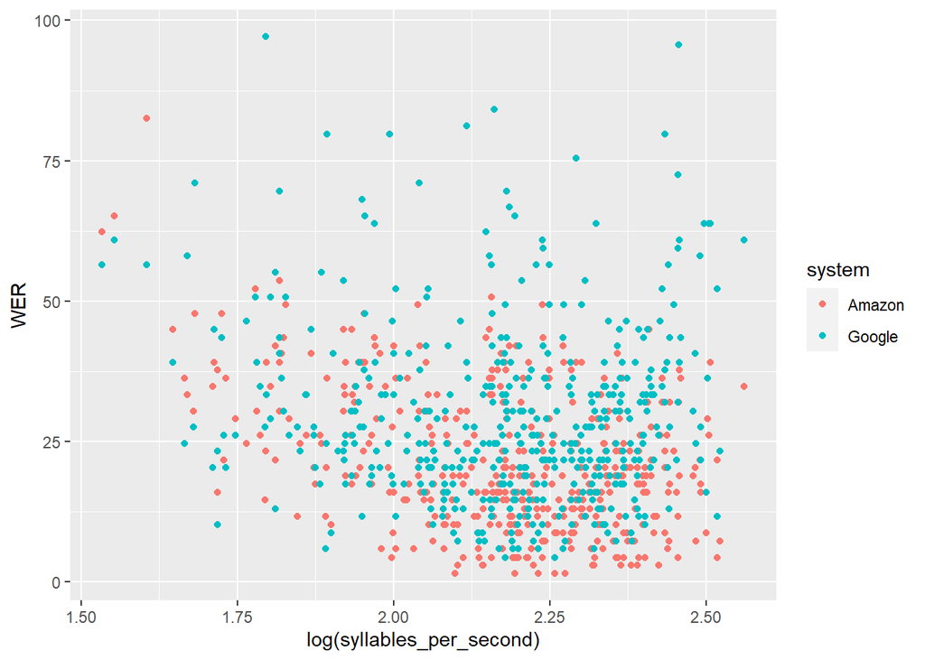

```r
saa_stella_long%>%
  ggplot(aes(log(syllables_per_second), WER,color = system))+
  geom_point()+
  scale_fill_colorblind()
```

The speechrate effect observed for SAA on Amazon appears to be caused by the higher WER for exceptionally slow speakers (who may well be disfluent):

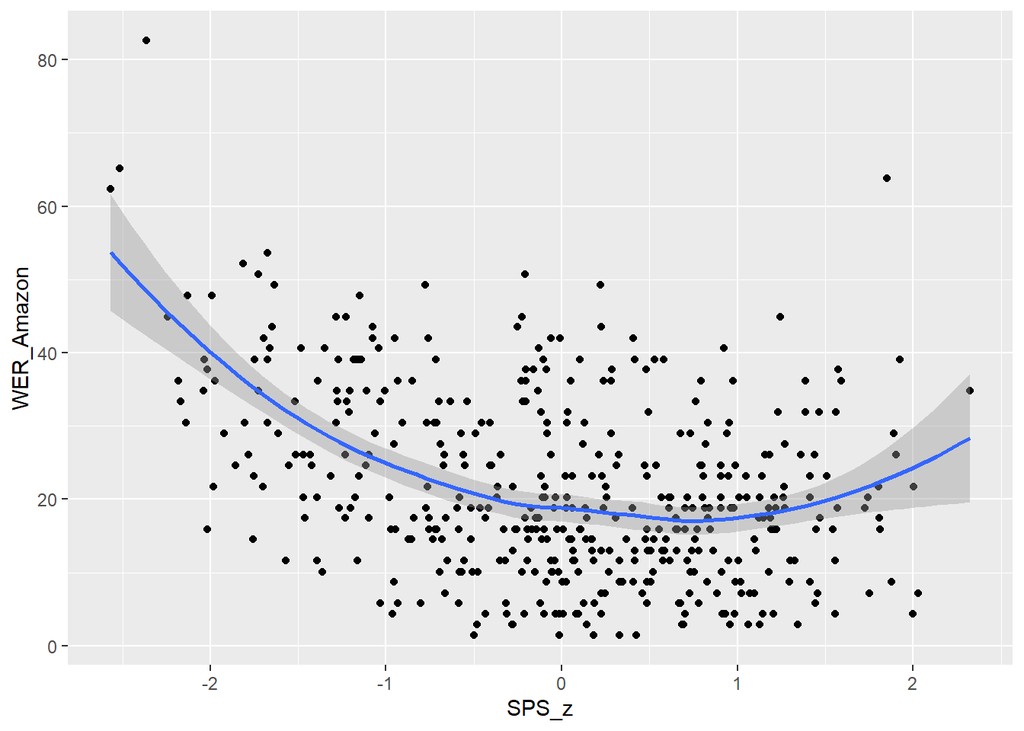

```r
saa_stella_wide%>%
  ggplot(aes(SPS_z, WER_Amazon))+
  geom_point()+
  geom_smooth()+
  scale_fill_colorblind()
```

In IViE this seems to be an issue for Google but not for Amazon

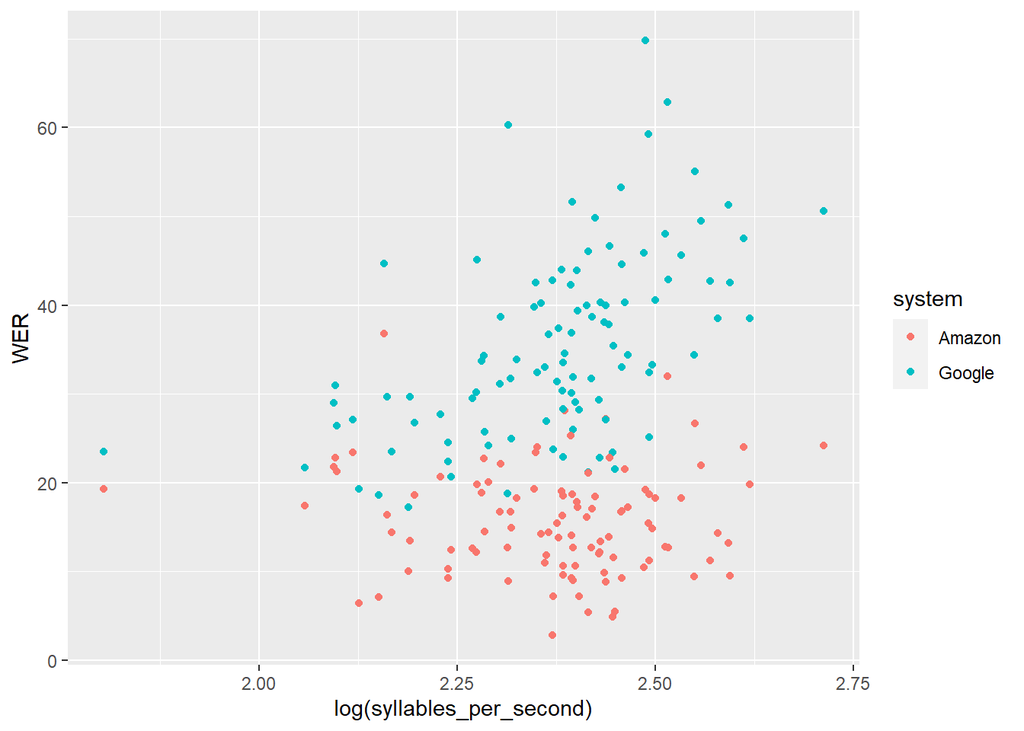

```r
ivie_rea1_long%>%
  ggplot(aes(log(syllables_per_second), WER,color = system))+
  geom_point()+
  scale_fill_colorblind()
```

## Sex:

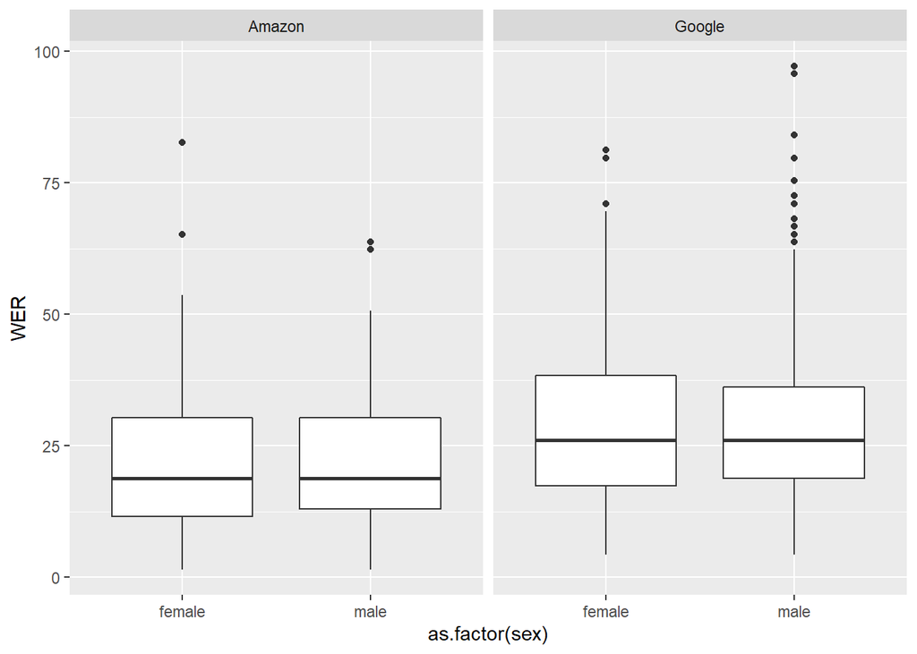

```r
saa_stella_long%>%
  ggplot(aes(as.factor(sex), WER))+
  geom_boxplot()+
  facet_grid(~system, scales = "free")
```

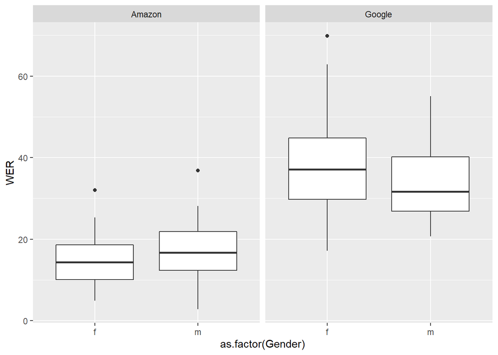

```r
ivie_rea1_long%>%
  ggplot(aes(as.factor(Gender), WER))+
  geom_boxplot()+
  facet_grid(~system, scales = "free")
```

Note that for Amazon, error rates are slightly (but perhaps not significantly?) higher for all corpora:

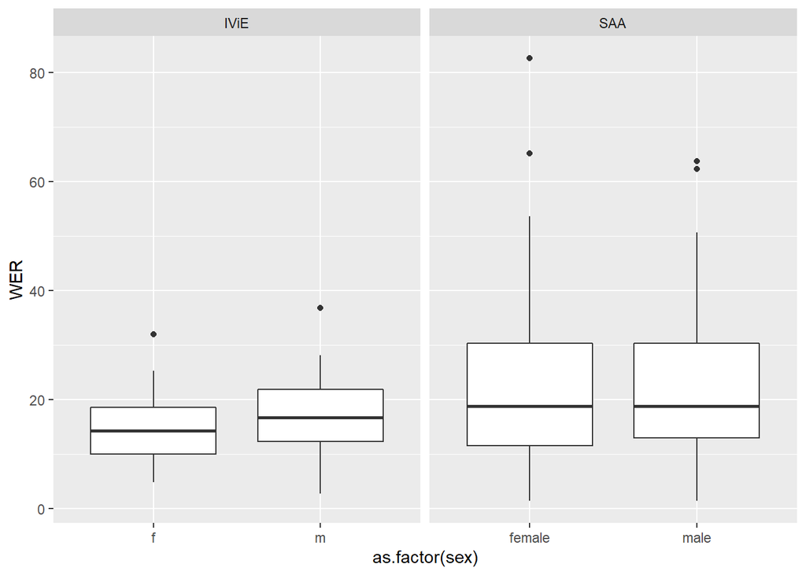

```r
facct_data_long%>%
  filter(system == "Amazon")%>%
  ggplot(aes(as.factor(sex), WER))+
  geom_boxplot()+
  facet_grid(~corpus, scales = "free")
```

## Age:

Age only varies for SAA, all IViE speakers are 16.

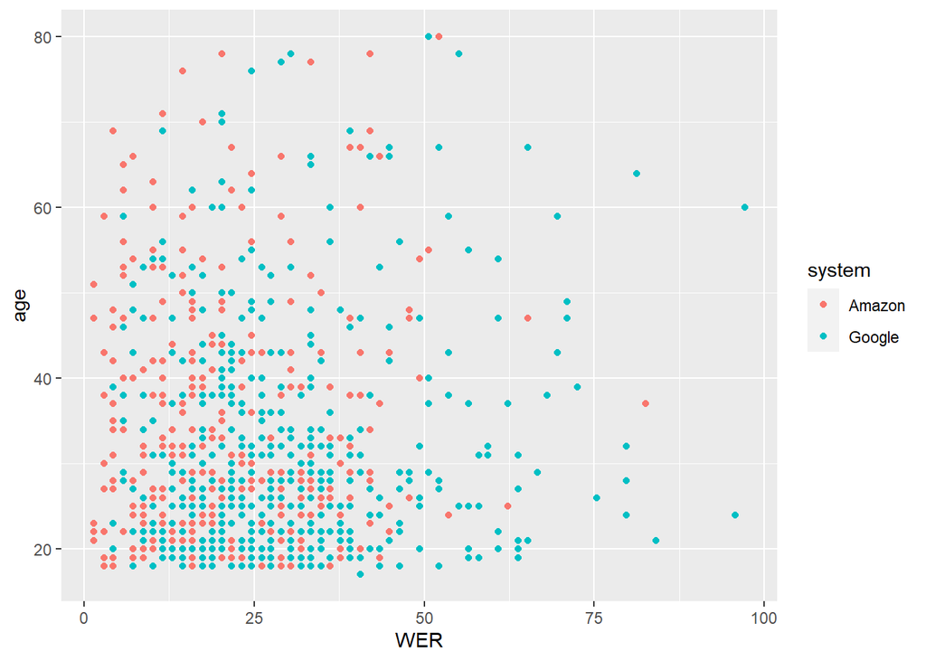

```r
saa_stella_long%>%
  ggplot(aes(WER, age, color = system))+
  geom_point()
```

For Google, this is significant but it’s also not a very clearly linear relationship:

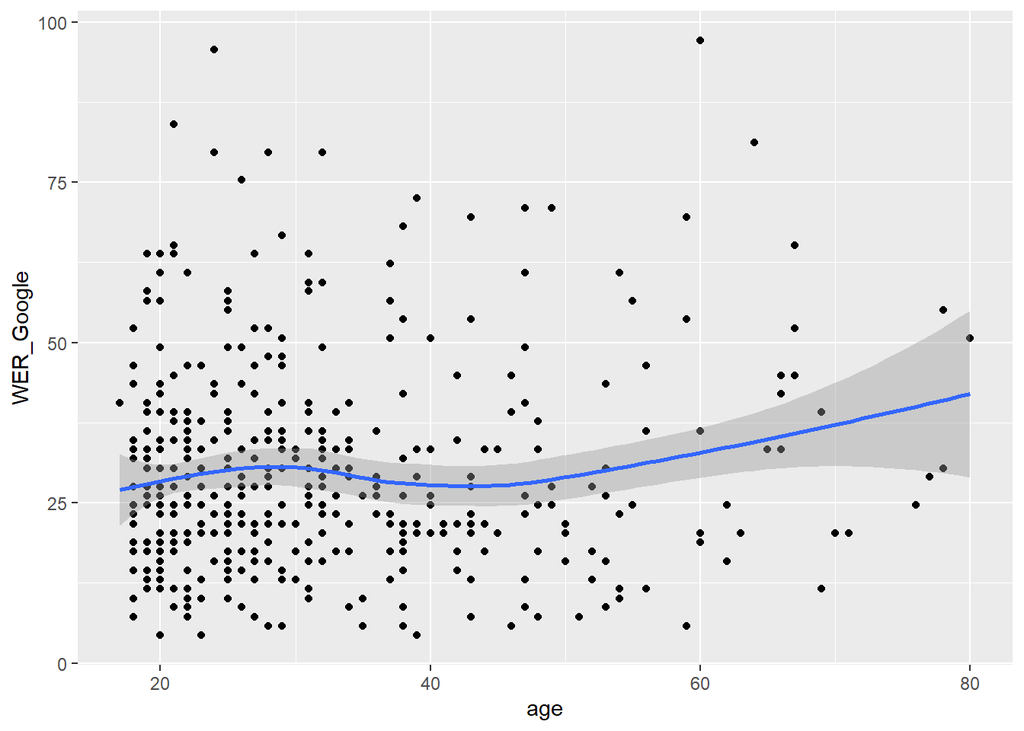

```r
saa_stella_wide%>%
  ggplot(aes(age, WER_Google))+
  geom_point()+
  geom_smooth()
```

## 5.1 L1/variety:

Higher error rate for non-native speakers in both systems. Overall error rate is lower in Amazon

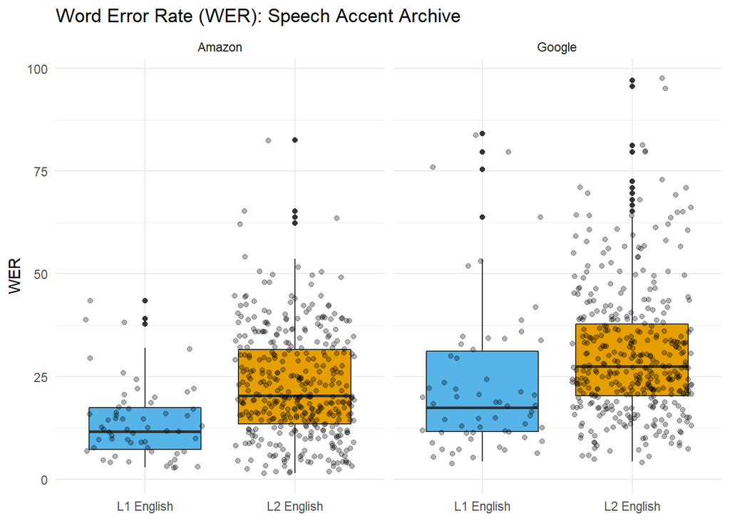

```r
saa_stella_long%>%
  mutate(L1_english = if_else(str_detect(native_language, "english"),"L1 English","L2 English"))%>%
  ggplot(aes(as.factor(L1_english), WER, fill = L1_english))+
  geom_boxplot()+
  geom_jitter(alpha = 0.3) +
  facet_grid(~system)+
    scale_fill_manual(values = c("#56B4E9", "#E69F00"))+
    theme_minimal()+
  theme(legend.position = "none",
        axis.title.x = element_blank()) +

  ggtitle("Word Error Rate (WER): Speech Accent Archive")
```

Looking at the bilingual vs monolingual speakers in IViE:

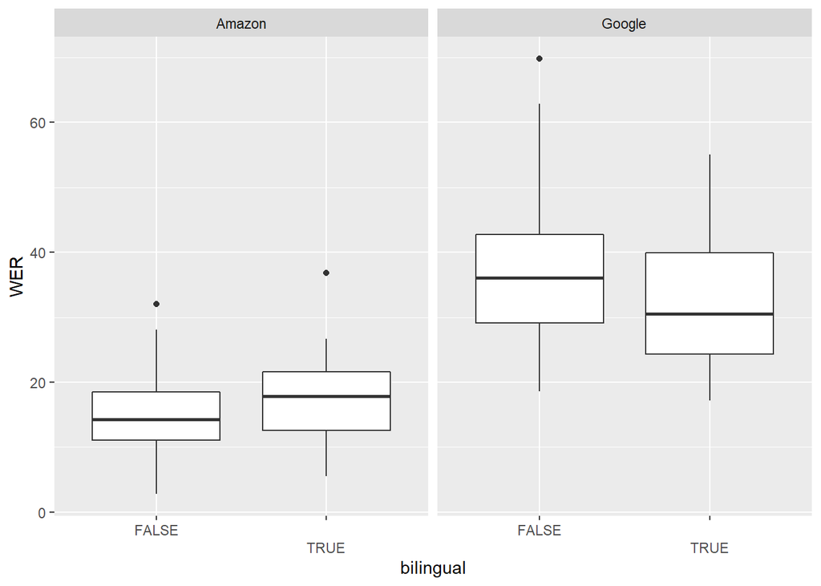

```r
ivie_rea1_long%>%
  mutate(bilingual = case_when(variety %in% c("Bradford Punjabi", "Cardiff Welsh", "London West Indian") ~ TRUE,
                               TRUE ~ FALSE))%>%
  ggplot(aes(bilingual, WER))+
  geom_boxplot()+
  facet_grid(~system)+
   scale_x_discrete(guide = guide_axis(n.dodge=2))
```

# 6 Stats:

## 6.1 SAA

Setting contrasts:

```r
saa_stella_wide$sex <- factor(saa_stella_wide$sex, levels = c("male", "female"))
contrasts(saa_stella_wide$sex) <- c(-0.5,0.5)
saa_stella_wide$L1_english <- factor(saa_stella_wide$L1_english, levels = c("L1_English", "L2_English"))
contrasts(saa_stella_wide$L1_english) <- c(-0.5,0.5)
```

### 6.1.1 Amazon:

```r
saa_ama_lm1 <- lm(WER_Amazon ~ L1_english + sex  + SPS_z + age_z, data = saa_stella_wide)
```

```r
saa_ama_lm1_inter <- lm(WER_Amazon ~ L1_english*sex  + SPS_z + age_z, data = saa_stella_wide)
```

```r
saa_ama_lm1%>%
  summ()
```

| Observations | 445 |
| --- | --- |
| Dependent variable | WER_Amazon |
| Type | OLS linear regression |

| F(4,440) | 20.69 |
| --- | --- |
| R² | 0.16 |
| Adj. R² | 0.15 |

|  | Est. | S.E. | t val. | p |
| --- | --- | --- | --- | --- |
| (Intercept) | 19.58 | 0.84 | 23.37 | 0.00 |
| L1_english1 | 5.14 | 1.71 | 3.01 | 0.00 |
| sex1 | -1.53 | 1.12 | -1.36 | 0.17 |
| SPS_z | -4.40 | 0.60 | -7.34 | 0.00 |
| age_z | -0.62 | 0.58 | -1.08 | 0.28 |

Standard errors: OLS

```r
summ(saa_ama_lm1_inter)
```

| Observations | 445 |
| --- | --- |
| Dependent variable | WER_Amazon |
| Type | OLS linear regression |

| F(5,439) | 16.79 |
| --- | --- |
| R² | 0.16 |
| Adj. R² | 0.15 |

|  | Est. | S.E. | t val. | p |
| --- | --- | --- | --- | --- |
| (Intercept) | 19.41 | 0.85 | 22.80 | 0.00 |
| L1_english1 | 5.51 | 1.74 | 3.17 | 0.00 |
| sex1 | -2.85 | 1.67 | -1.71 | 0.09 |
| SPS_z | -4.39 | 0.60 | -7.32 | 0.00 |
| age_z | -0.64 | 0.58 | -1.11 | 0.27 |
| L1_english1:sex1 | 3.57 | 3.33 | 1.07 | 0.28 |

Standard errors: OLS

Model comparison:

```r
anova(saa_ama_lm1, saa_ama_lm1_inter)
```

|  | Res.Df | RSS | Df | Sum of Sq | F | Pr(>F) |
| --- | --- | --- | --- | --- | --- | --- |
| 1 | 440 | 59605.73 | NA | NA | NA | NA |
| 2 | 439 | 59450.03 | 1 | 155.6975 | 1.149725 | 0.2841957 |

### 6.1.2 Google:

```r
saa_google_lm1 <- lm(WER_Google ~ L1_english + sex  + SPS_z + age_z, data = saa_stella_wide)
```

```r
summ(saa_google_lm1)
```

| Observations | 445 |
| --- | --- |
| Dependent variable | WER_Google |
| Type | OLS linear regression |

| F(4,440) | 4.04 |
| --- | --- |
| R² | 0.04 |
| Adj. R² | 0.03 |

|  | Est. | S.E. | t val. | p |
| --- | --- | --- | --- | --- |
| (Intercept) | 26.55 | 1.15 | 23.07 | 0.00 |
| L1_english1 | 7.91 | 2.34 | 3.37 | 0.00 |
| sex1 | -1.45 | 1.54 | -0.94 | 0.35 |
| SPS_z | 0.09 | 0.82 | 0.11 | 0.92 |
| age_z | 1.66 | 0.79 | 2.10 | 0.04 |

Standard errors: OLS

```r
saa_google_lm1_inter <- lm(WER_Google ~ L1_english * sex  + SPS_z + age_z, data = saa_stella_wide)
```

```r
summ(saa_google_lm1_inter)
```

| Observations | 445 |
| --- | --- |
| Dependent variable | WER_Google |
| Type | OLS linear regression |

| F(5,439) | 3.42 |
| --- | --- |
| R² | 0.04 |
| Adj. R² | 0.03 |

|  | Est. | S.E. | t val. | p |
| --- | --- | --- | --- | --- |
| (Intercept) | 26.34 | 1.17 | 22.52 | 0.00 |
| L1_english1 | 8.37 | 2.39 | 3.50 | 0.00 |
| sex1 | -3.10 | 2.29 | -1.35 | 0.18 |
| SPS_z | 0.11 | 0.82 | 0.13 | 0.90 |
| age_z | 1.64 | 0.79 | 2.07 | 0.04 |
| L1_english1:sex1 | 4.46 | 4.57 | 0.98 | 0.33 |

Standard errors: OLS

```r
anova(saa_google_lm1, saa_google_lm1_inter)
```

|  | Res.Df | RSS | Df | Sum of Sq | F | Pr(>F) |
| --- | --- | --- | --- | --- | --- | --- |
| 1 | 440 | 112494.4 | NA | NA | NA | NA |
| 2 | 439 | 112250.8 | 1 | 243.5782 | 0.9526065 | 0.3295942 |

## 6.2 IViE:

Setting contrasts:

```r
ivie_rea1_wide$Gender <- factor(ivie_rea1_wide$Gender, levels = c("m", "f"))
contrasts(ivie_rea1_wide$Gender) <- c(-0.5,0.5)
```

### 6.2.1 Amazon:

For Amazon, Cambridge speakers have the lowest WER - so we set Cambridge as reference level to compare the other varieties against.

```r
ivie_rea1_wide$variety <- factor(ivie_rea1_wide$variety, levels = c("Cambridge", "Cardiff Welsh", "Bradford Punjabi", "Leeds", "Liverpool", "London West Indian", "Newcastle", "Belfast", "Dublin"))
```

```r
ivie_ama_lm1 <- lm(WER_Amazon ~ variety + Gender  + SPS_z, data = ivie_rea1_wide)
```

```r
summ(ivie_ama_lm1)
```

| Observations | 102 |
| --- | --- |
| Dependent variable | WER_Amazon |
| Type | OLS linear regression |

| F(10,91) | 3.91 |
| --- | --- |
| R² | 0.30 |
| Adj. R² | 0.22 |

|  | Est. | S.E. | t val. | p |
| --- | --- | --- | --- | --- |
| (Intercept) | 11.21 | 1.56 | 7.19 | 0.00 |
| varietyCardiff Welsh | 4.45 | 2.50 | 1.78 | 0.08 |
| varietyBradford Punjabi | 8.84 | 2.18 | 4.05 | 0.00 |
| varietyLeeds | 1.43 | 2.23 | 0.64 | 0.52 |
| varietyLiverpool | 6.00 | 2.20 | 2.72 | 0.01 |
| varietyLondon West Indian | 4.80 | 2.39 | 2.01 | 0.05 |
| varietyNewcastle | 5.25 | 2.19 | 2.40 | 0.02 |
| varietyBelfast | 9.03 | 2.19 | 4.13 | 0.00 |
| varietyDublin | 1.18 | 2.23 | 0.53 | 0.60 |
| Gender1 | -2.67 | 1.11 | -2.42 | 0.02 |
| SPS_z | 0.22 | 0.63 | 0.35 | 0.73 |

Standard errors: OLS

```r
ivie_ama_lm1_inter <- lm(WER_Amazon ~ variety* Gender  + SPS_z, data = ivie_rea1_wide)
```

```r
summ(ivie_ama_lm1_inter)
```

| Observations | 102 |
| --- | --- |
| Dependent variable | WER_Amazon |
| Type | OLS linear regression |

| F(18,83) | 3.24 |
| --- | --- |
| R² | 0.41 |
| Adj. R² | 0.28 |

|  | Est. | S.E. | t val. | p |
| --- | --- | --- | --- | --- |
| (Intercept) | 11.14 | 1.50 | 7.42 | 0.00 |
| varietyCardiff Welsh | 4.62 | 2.41 | 1.92 | 0.06 |
| varietyBradford Punjabi | 8.98 | 2.10 | 4.27 | 0.00 |
| varietyLeeds | 1.36 | 2.14 | 0.64 | 0.53 |
| varietyLiverpool | 6.02 | 2.13 | 2.82 | 0.01 |
| varietyLondon West Indian | 5.80 | 2.34 | 2.47 | 0.02 |
| varietyNewcastle | 5.32 | 2.11 | 2.53 | 0.01 |
| varietyBelfast | 9.10 | 2.10 | 4.33 | 0.00 |
| varietyDublin | 1.29 | 2.15 | 0.60 | 0.55 |
| Gender1 | 2.33 | 2.96 | 0.79 | 0.43 |
| SPS_z | 0.41 | 0.67 | 0.62 | 0.54 |
| varietyCardiff Welsh:Gender1 | 1.47 | 4.68 | 0.31 | 0.76 |
| varietyBradford Punjabi:Gender1 | -7.11 | 4.34 | -1.64 | 0.11 |
| varietyLeeds:Gender1 | -6.76 | 4.31 | -1.57 | 0.12 |
| varietyLiverpool:Gender1 | -4.17 | 4.21 | -0.99 | 0.33 |
| varietyLondon West Indian:Gender1 | -13.57 | 4.22 | -3.22 | 0.00 |
| varietyNewcastle:Gender1 | -3.08 | 4.21 | -0.73 | 0.47 |
| varietyBelfast:Gender1 | -4.32 | 4.18 | -1.03 | 0.30 |
| varietyDublin:Gender1 | -6.71 | 4.30 | -1.56 | 0.12 |

Standard errors: OLS

Adding the interaction does not improve fit significantly:

```r
anova(ivie_ama_lm1, ivie_ama_lm1_inter)
```

|  | Res.Df | RSS | Df | Sum of Sq | F | Pr(>F) |
| --- | --- | --- | --- | --- | --- | --- |
| 1 | 91 | 2589.029 | NA | NA | NA | NA |
| 2 | 83 | 2175.338 | 8 | 413.6908 | 1.973046 | 0.05993073 |

### 6.2.2 Google:

For Google, London speakers have the lowest error rate. Let’s set London as reference level instead:

```r
ivie_rea1_wide$variety <- factor(ivie_rea1_wide$variety, levels = c("London West Indian", "Cambridge", "Cardiff Welsh", "Bradford Punjabi", "Leeds", "Liverpool" , "Newcastle", "Belfast", "Dublin"))
```

```r
ivie_google_lm1 <- lm(WER_Google ~ variety + Gender  + SPS_z, data = ivie_rea1_wide)
```

```r
summ(ivie_google_lm1)
```

| Observations | 102 |
| --- | --- |
| Dependent variable | WER_Google |
| Type | OLS linear regression |

| F(10,91) | 6.74 |
| --- | --- |
| R² | 0.43 |
| Adj. R² | 0.36 |

|  | Est. | S.E. | t val. | p |
| --- | --- | --- | --- | --- |
| (Intercept) | 33.29 | 2.70 | 12.34 | 0.00 |
| varietyCambridge | 1.98 | 3.78 | 0.52 | 0.60 |
| varietyCardiff Welsh | 1.18 | 3.91 | 0.30 | 0.76 |
| varietyBradford Punjabi | 1.68 | 3.84 | 0.44 | 0.66 |
| varietyLeeds | -3.09 | 3.83 | -0.81 | 0.42 |
| varietyLiverpool | 4.55 | 3.60 | 1.26 | 0.21 |
| varietyNewcastle | 1.39 | 3.64 | 0.38 | 0.70 |
| varietyBelfast | 10.88 | 3.65 | 2.98 | 0.00 |
| varietyDublin | -0.18 | 3.76 | -0.05 | 0.96 |
| Gender1 | 0.94 | 1.75 | 0.54 | 0.59 |
| SPS_z | 5.58 | 1.00 | 5.56 | 0.00 |

Standard errors: OLS

```r
ivie_google_lm1_inter <- lm(WER_Google ~ variety * Gender  + SPS_z, data = ivie_rea1_wide)
```

```r
summ(ivie_google_lm1_inter)
```

| Observations | 102 |
| --- | --- |
| Dependent variable | WER_Google |
| Type | OLS linear regression |

| F(18,83) | 6.91 |
| --- | --- |
| R² | 0.60 |
| Adj. R² | 0.51 |

|  | Est. | S.E. | t val. | p |
| --- | --- | --- | --- | --- |
| (Intercept) | 35.01 | 2.43 | 14.40 | 0.00 |
| varietyCambridge | -0.07 | 3.38 | -0.02 | 0.98 |
| varietyCardiff Welsh | -0.12 | 3.45 | -0.03 | 0.97 |
| varietyBradford Punjabi | 0.48 | 3.41 | 0.14 | 0.89 |
| varietyLeeds | -5.07 | 3.41 | -1.49 | 0.14 |
| varietyLiverpool | 2.82 | 3.22 | 0.88 | 0.38 |
| varietyNewcastle | -0.34 | 3.24 | -0.11 | 0.92 |
| varietyBelfast | 9.11 | 3.25 | 2.80 | 0.01 |
| varietyDublin | -1.68 | 3.37 | -0.50 | 0.62 |
| Gender1 | -8.72 | 4.38 | -1.99 | 0.05 |
| SPS_z | 6.41 | 0.96 | 6.67 | 0.00 |
| varietyCambridge:Gender1 | 8.31 | 6.08 | 1.37 | 0.18 |
| varietyCardiff Welsh:Gender1 | 15.55 | 6.83 | 2.28 | 0.03 |
| varietyBradford Punjabi:Gender1 | -2.21 | 6.24 | -0.35 | 0.72 |
| varietyLeeds:Gender1 | 9.68 | 6.31 | 1.53 | 0.13 |
| varietyLiverpool:Gender1 | 10.48 | 6.12 | 1.71 | 0.09 |
| varietyNewcastle:Gender1 | 12.73 | 6.09 | 2.09 | 0.04 |
| varietyBelfast:Gender1 | 28.34 | 6.09 | 4.65 | 0.00 |
| varietyDublin:Gender1 | 1.35 | 6.28 | 0.22 | 0.83 |

Standard errors: OLS

Adding the interaction improves model fit here:

```r
anova(ivie_google_lm1, ivie_google_lm1_inter)
```

|  | Res.Df | RSS | Df | Sum of Sq | F | Pr(>F) |
| --- | --- | --- | --- | --- | --- | --- |
| 1 | 91 | 6500.154 | NA | NA | NA | NA |
| 2 | 83 | 4529.504 | 8 | 1970.65 | 4.513848 | 0.0001392833 |

# 7 Qualitative error analysis:

## 7.1 SAA:

### 7.1.1 Error Type:

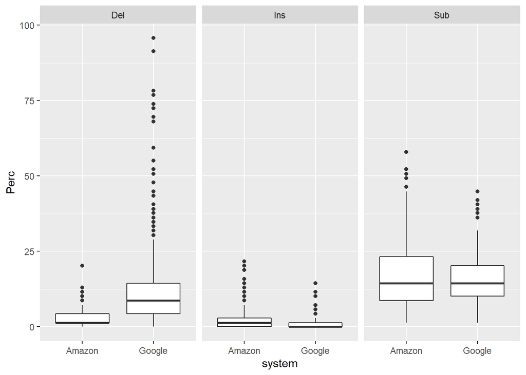

```r
saa_stella_long%>%
  pivot_longer(cols = c("Sub", "Del", "Ins"), names_to = "ErrorType", values_to = "Perc")%>%
  ggplot(aes(system, Perc))+
  geom_boxplot()+
  facet_grid(~ErrorType)
```

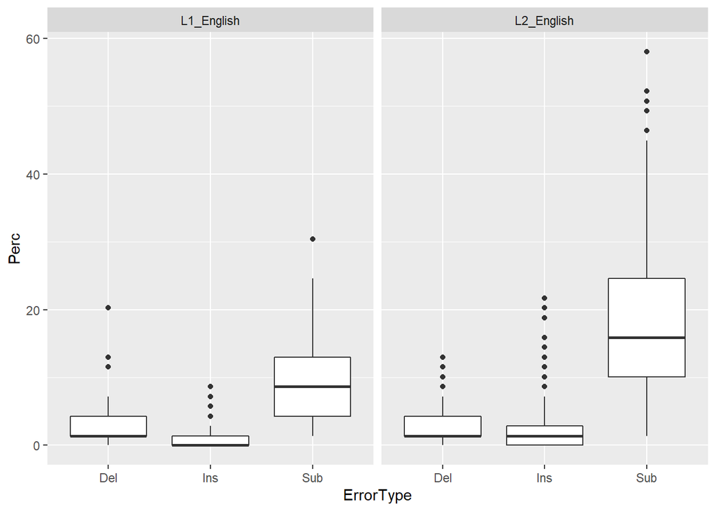

```r
saa_stella_long%>%
  filter(system == "Amazon")%>%
  pivot_longer(cols = c("Sub", "Del", "Ins"), names_to = "ErrorType", values_to = "Perc")%>%
  ggplot(aes(ErrorType, Perc))+
  geom_boxplot()+
  facet_grid(~L1_english)
```

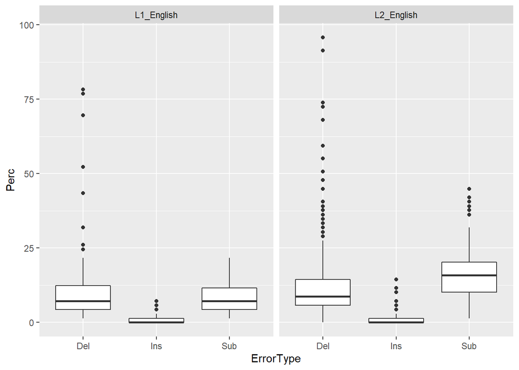

```r
saa_stella_long%>%
  filter(system == "Google")%>%

  pivot_longer(cols = c("Sub", "Del", "Ins"), names_to = "ErrorType", values_to = "Perc")%>%
  ggplot(aes(ErrorType, Perc))+
  geom_boxplot()+
  facet_grid(~L1_english)
```

### 7.1.2 Confusion pairs

We also have information about confusion pairs:

```r
ama_confusion_pairs_saa <- read.csv(paste0(data_path, '/Data/SpeechAccentArchive/error_analysis/amazon_confusion_summary.csv'), encoding = 'UTF-8')%>%
  mutate(system = "Amazon",
         Speaker = paste0("SAA", str_extract(Filename, "[^_]+") ))
```

```r
google_confusion_pairs_saa <- read.csv(paste0(data_path, '/Data/SpeechAccentArchive/error_analysis/google_confusion_summary.csv'), encoding = 'UTF-8')%>%
  mutate(ASR = enc2utf8(ASR))%>%
  mutate(system = "Google",
         Speaker = paste0("SAA", str_extract(Filename, "[^_]+") ))
```

```r
saa_demog_min <- saa_stella_wide%>%
  select(Speaker, native_language)
```

```r
stella_confusion <- bind_rows(google_confusion_pairs_saa, ama_confusion_pairs_saa)%>%
  right_join(saa_demog_min, by = "Speaker")%>%
  distinct()
```

```r
stella_confusion_pairs <- stella_confusion%>%
 mutate(correct = str_trim(correct, side = "both"))%>%
  mutate(ASR = stri_enc_toutf8(ASR))%>%
  mutate(pair = paste(correct, ASR, sep = ':'))%>%
  mutate(pair = as.factor(str_trim(pair, side = "both")))%>%
  group_by(system, native_language, pair)%>%
  mutate(pair_count_var = n())%>%
  ungroup()
```

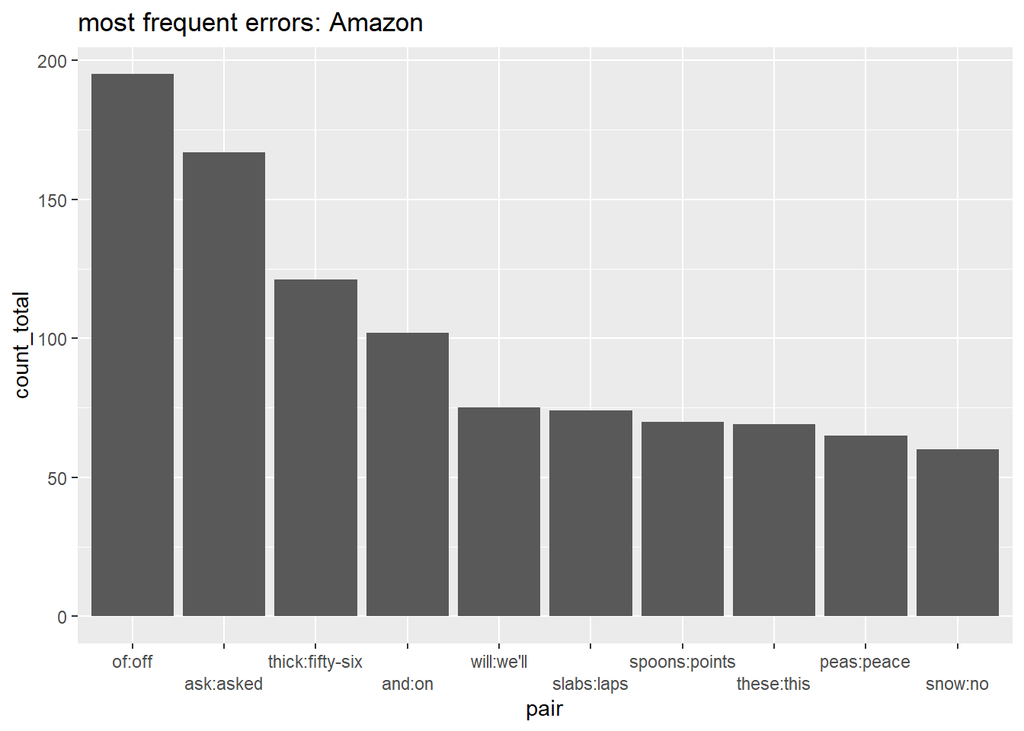

```r
stella_confusion_pairs%>%
  filter(system == "Amazon")%>%
  group_by(pair)%>%
  summarise(count_total = n())%>%
  arrange(desc(count_total))%>%
  head(10)%>%
  mutate(pair = factor(pair, pair)) %>%   # reset factor
  ggplot(aes(pair, count_total))+
  geom_bar(stat='identity')+
    ggtitle("most frequent errors: Amazon")+
   scale_x_discrete(guide = guide_axis(n.dodge=2))
```

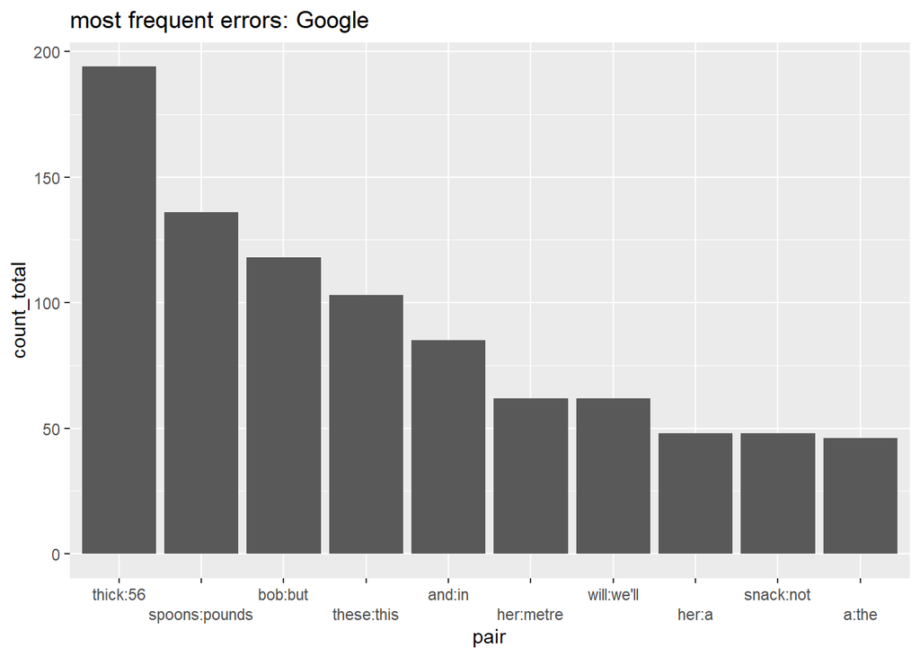

```r
stella_confusion_pairs%>%
  filter(system == "Google")%>%
  group_by(pair)%>%
  summarise(count_total = n())%>%
  arrange(desc(count_total))%>%
  head(10)%>%
  mutate(pair = factor(pair, pair)) %>%   # reset factor
  ggplot(aes(pair, count_total))+
  geom_bar(stat='identity')+
    ggtitle("most frequent errors: Google")+
   scale_x_discrete(guide = guide_axis(n.dodge=2))
```

## 7.2 IViE:

### 7.2.1 Error Type:

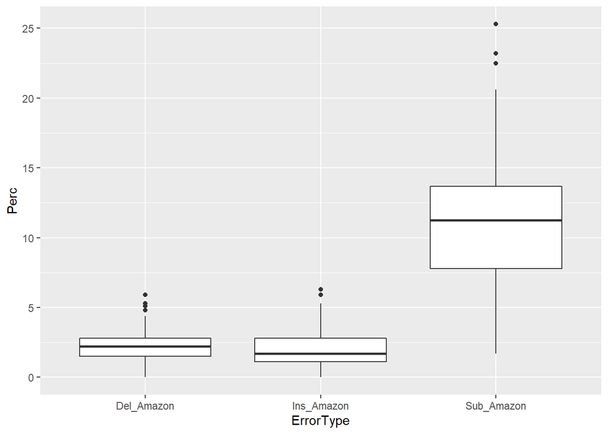

```r
ivie_rea1_wide%>%
  pivot_longer(cols = c("Sub_Amazon", "Del_Amazon", "Ins_Amazon"), names_to = "ErrorType", values_to = "Perc")%>%
  ggplot(aes(ErrorType, Perc))+
  geom_boxplot()
```

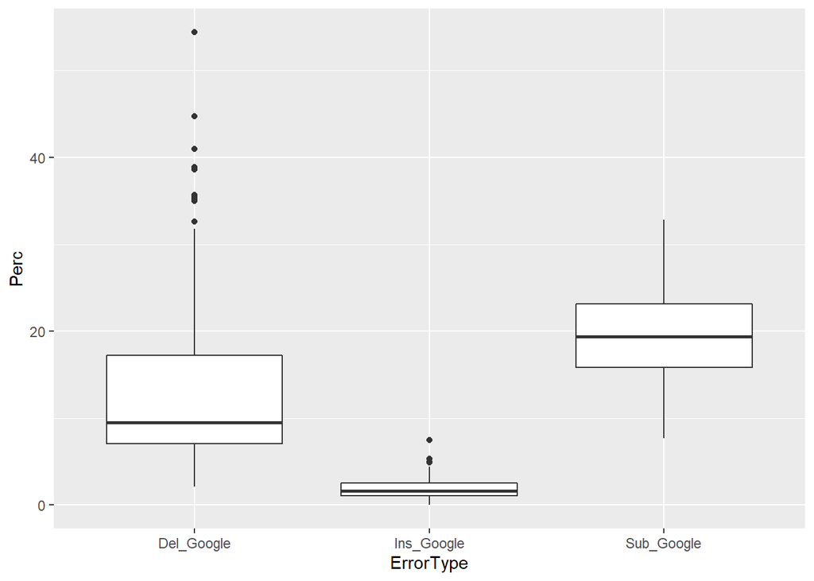

```r
ivie_rea1_wide%>%
  pivot_longer(cols = c("Sub_Google", "Del_Google", "Ins_Google"), names_to = "ErrorType", values_to = "Perc")%>%
  ggplot(aes(ErrorType, Perc))+
  geom_boxplot()
```

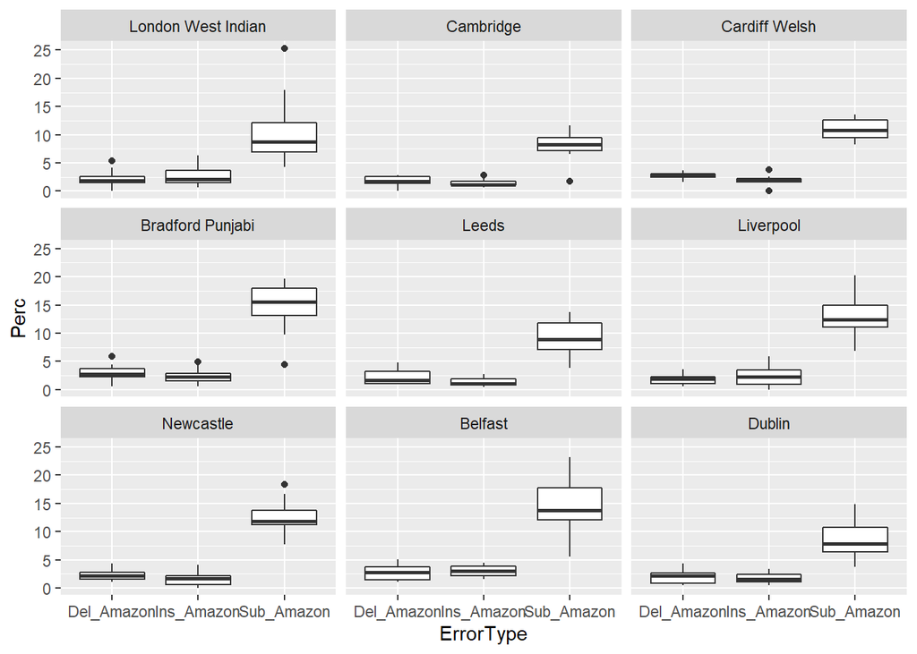

```r
ivie_rea1_wide%>%
  pivot_longer(cols = c("Sub_Amazon", "Del_Amazon", "Ins_Amazon"), names_to = "ErrorType", values_to = "Perc")%>%
  ggplot(aes(ErrorType, Perc))+
  geom_boxplot()+
  facet_wrap(~variety)
```

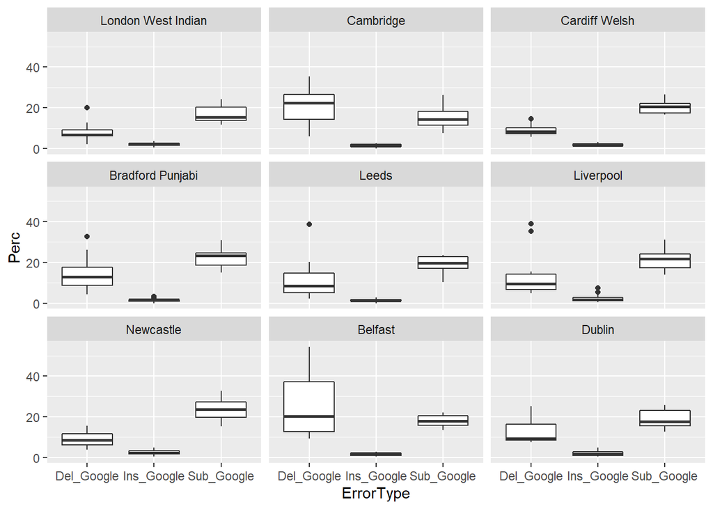

```r
ivie_rea1_wide%>%
  pivot_longer(cols = c("Sub_Google", "Del_Google", "Ins_Google"), names_to = "ErrorType", values_to = "Perc")%>%
  ggplot(aes(ErrorType, Perc))+
  geom_boxplot()+
  facet_wrap(~variety)
```

### 7.2.2 Confusion pairs

```r
ama_confusion_pairs_ivie <- read.csv(paste0(data_path, "/Data/IViE/error_analysis/amazon_confusion_summary.csv"), encoding = 'UTF-8')%>%
  mutate(system = "Amazon",
         Speaker = str_replace(as.character(Filename), "_hyp.trn.dtl", ""),
         Speaker = str_replace(as.character(Speaker), "-rea1", ""))
```

```r
google_confusion_pairs_ivie <- read.csv(paste0(data_path, "/Data/IViE/error_analysis/google_confusion_summary.csv"), encoding = 'UTF-8')%>%
  mutate(system = "Google",
         Speaker = str_replace(as.character(Filename), "_hyp.trn.dtl", ""),
         Speaker = str_replace(as.character(Speaker), "-rea1", ""))
```

```r
ivie_demog_min <- ivie_rea1_wide%>%
  select(Speaker, variety)
```

```r
ivie_confusion <- bind_rows(google_confusion_pairs_ivie, ama_confusion_pairs_ivie)%>%
  left_join(ivie_demog_min, by = c("Speaker"))
```

```r
ivie_confusion_pairs <-
  ivie_confusion%>%
  mutate(correct = str_trim(correct, side = "both"))%>%
  mutate(ASR = stri_enc_toutf8(ASR))%>%
  mutate(pair = paste(correct, ASR, sep = ':'))%>%
  mutate(pair = as.factor(str_trim(pair, side = "both")))%>%
  group_by(system, variety, pair)%>%
  mutate(pair_count_var = n())%>%
  ungroup()
```

If we look at them generally it’s not particularly interesting

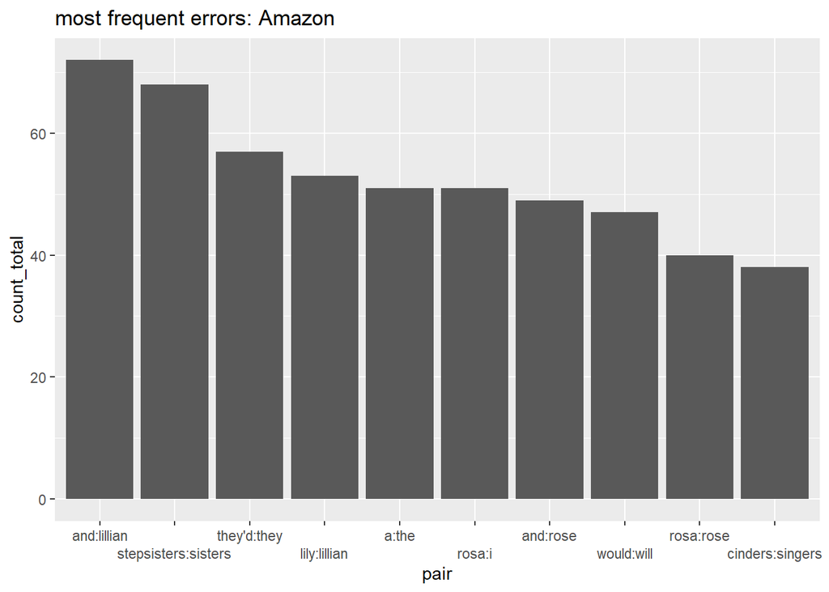

```r
ivie_confusion_pairs%>%
  filter(system == "Amazon")%>%
  group_by(pair)%>%
  summarise(count_total = n())%>%
  arrange(desc(count_total))%>%
  head(10)%>%
  mutate(pair = factor(pair, pair)) %>%   # reset factor
  ggplot(aes(pair, count_total))+
  geom_bar(stat='identity')+
    ggtitle("most frequent errors: Amazon")+
   scale_x_discrete(guide = guide_axis(n.dodge=2))
```

```r
ivie_confusion_pairs%>%
  filter(system == "Amazon")%>%
  group_by(pair)%>%
  summarise(count_total = n())%>%
  arrange(desc(count_total))
```

| pair | count_total |
| --- | --- |
| and:lillian | 72 |
| stepsisters:sisters | 68 |
| they'd:they | 57 |
| lily:lillian | 53 |
| a:the | 51 |
| rosa:i | 51 |
| and:rose | 49 |
| would:will | 47 |
| rosa:rose | 40 |
| cinders:singers | 38 |

[output cut: 764 more lines]

```r
ivie_confusion_pairs%>%
  filter(system == "Google")%>%
  group_by(pair)%>%
  summarise(count_total = n())%>%
  arrange(desc(count_total))
```

| pair | count_total |
| --- | --- |
| their:the | 79 |
| lived:live | 59 |
| buying:by | 52 |
| hairbrushes:hair | 48 |
| rosa:rosie | 48 |
| hairpins:pins | 43 |
| they'd:they | 43 |
| sisters:sister's | 42 |
| would:will | 41 |
| dreamed:dream | 40 |

[output cut: 1463 more lines]

Belfast: “hair” > “her”

```r
ivie_confusion_pairs%>%
  filter(system == "Amazon" & variety == "Belfast")%>%
  group_by(pair)%>%
  arrange(desc(pair_count_var))%>%
  select(correct, ASR, pair_count_var)%>%
  distinct()
```

| pair | correct | ASR | pair_count_var |
| --- | --- | --- | --- |
| and:lillian | and | lillian | 11 |
| hairbrushes:her | hairbrushes | her | 9 |
| cinders:percenters | cinders | percenters | 8 |
| would:will | would | will | 8 |
| gowns:guns | gowns | guns | 7 |
| hairpins:pins | hairpins | pins | 7 |
| they'd:they | they'd | they | 6 |
| stepsisters:sisters | stepsisters | sisters | 6 |
| gowns:grounds | gowns | grounds | 5 |
| a:the | a | the | 5 |

[output cut: 165 more lines]

```r
ivie_confusion_pairs%>%
  filter(system == "Google" & variety == "Belfast")%>%
  group_by(pair)%>%
  arrange(desc(pair_count_var))%>%
  select(correct, ASR, pair_count_var)%>%
  distinct()
```

| pair | correct | ASR | pair_count_var |
| --- | --- | --- | --- |
| would:will | would | will | 8 |
| hairbrushes:her | hairbrushes | her | 8 |
| their:the | their | the | 6 |
| lived:live | lived | live | 5 |
| cinders:percentages | cinders | percentages | 5 |
| dreamed:dream | dreamed | dream | 5 |
| rosa:rosie | rosa | rosie | 4 |
| buying:by | buying | by | 4 |
| were:there | were | there | 4 |
| hairpins:pens | hairpins | pens | 4 |

[output cut: 269 more lines]

Cardiff: “gowns” > “guns”, “royal” > “real”, “howled” > “hold/old”

```r
ivie_confusion_pairs%>%
  filter(system == "Amazon" & variety == "Cardiff Welsh")%>%
  group_by(pair)%>%
  arrange(desc(pair_count_var))%>%
  select(correct, ASR, pair_count_var)%>%
  distinct()
```

| pair | correct | ASR | pair_count_var |
| --- | --- | --- | --- |
| and:lillian | and | lillian | 8 |
| their:the | their | the | 5 |
| lily:lillian | lily | lillian | 5 |
| cinders:singers | cinders | singers | 4 |
| stepsisters:sisters | stepsisters | sisters | 4 |
| and:rose | and | rose | 4 |
| howled:hold | howled | hold | 4 |
| rosa:rose | rosa | rose | 3 |
| gowns:guns | gowns | guns | 3 |
| rosa:i | rosa | i | 3 |

[output cut: 87 more lines]

Newcastle: “howled” > “held”

```r
ivie_confusion_pairs%>%
  filter(system == "Amazon" & variety == "Newcastle")%>%
  group_by(pair)%>%
  arrange(desc(pair_count_var))%>%
  select(correct, ASR, pair_count_var)%>%
  distinct()
```

| pair | correct | ASR | pair_count_var |
| --- | --- | --- | --- |
| a:the | a | the | 9 |
| rosa:i | rosa | i | 9 |
| and:lillian | and | lillian | 7 |
| lily:lillian | lily | lillian | 7 |
| howled:held | howled | held | 6 |
| they'd:they | they'd | they | 6 |
| would:will | would | will | 6 |
| cinders:does | cinders | does | 5 |
| gowns:guns | gowns | guns | 5 |
| and:in | and | in | 4 |

[output cut: 146 more lines]

Bradford: “gowns” > “guns”

```r
ivie_confusion_pairs%>%
  filter(system == "Amazon" & variety == "Bradford Punjabi")%>%
  group_by(pair)%>%
  arrange(desc(pair_count_var))%>%
  select(correct, ASR, pair_count_var)%>%
  distinct()
```

| pair | correct | ASR | pair_count_var |
| --- | --- | --- | --- |
| stepsisters:sisters | stepsisters | sisters | 11 |
| they'd:they | they'd | they | 10 |
| their:the | their | the | 9 |
| cinders:singers | cinders | singers | 6 |
| cinders:passengers | cinders | passengers | 6 |
| gowns:guns | gowns | guns | 6 |
| rosa:i | rosa | i | 5 |
| and:lillian | and | lillian | 5 |
| a:the | a | the | 4 |
| hat:heart | hat | heart | 4 |

[output cut: 168 more lines]

```r
ivie_confusion_pairs%>%
  filter(system == "Amazon" & variety == "Cambridge")%>%
  group_by(pair)%>%
  arrange(desc(pair_count_var))%>%
  select(correct, ASR, pair_count_var)%>%
  distinct()
```

| pair | correct | ASR | pair_count_var |
| --- | --- | --- | --- |
| and:lillian | and | lillian | 11 |
| stepsisters:sisters | stepsisters | sisters | 10 |
| and:rose | and | rose | 9 |
| cinders:singers | cinders | singers | 9 |
| lily:lillian | lily | lillian | 9 |
| rosa:i | rosa | i | 9 |
| howled:held | howled | held | 7 |
| rosa:rose | rosa | rose | 7 |
| they'd:they | they'd | they | 7 |
| would:will | would | will | 5 |

[output cut: 60 more lines]

```r
ivie_confusion_pairs%>%
  filter(system == "Amazon" & variety == "Liverpool")%>%
  group_by(pair)%>%
  arrange(desc(pair_count_var))%>%
  select(correct, ASR, pair_count_var)%>%
  distinct()
```

| pair | correct | ASR | pair_count_var |
| --- | --- | --- | --- |
| would:will | would | will | 12 |
| a:the | a | the | 10 |
| and:rose | and | rose | 10 |
| lily:lillian | lily | lillian | 10 |
| stepsisters:sisters | stepsisters | sisters | 9 |
| and:lillian | and | lillian | 8 |
| rosa:rose | rosa | rose | 8 |
| cinders:singers | cinders | singers | 6 |
| they'd:they | they'd | they | 6 |
| her:his | her | his | 6 |

[output cut: 143 more lines]

```r
ivie_confusion_pairs%>%
  filter(system == "Amazon" & variety == "Dublin")%>%
  group_by(pair)%>%
  arrange(desc(pair_count_var))%>%
  select(correct, ASR, pair_count_var)%>%
  distinct()
```

| pair | correct | ASR | pair_count_var |
| --- | --- | --- | --- |
| and:lillian | and | lillian | 9 |
| howled:held | howled | held | 9 |
| a:the | a | the | 8 |
| stepsisters:sisters | stepsisters | sisters | 8 |
| they'd:they | they'd | they | 7 |
| cinders:singers | cinders | singers | 6 |
| and:rose | and | rose | 5 |
| lily:lillian | lily | lillian | 5 |
| rosa:i | rosa | i | 5 |
| rosa:rose | rosa | rose | 4 |

[output cut: 83 more lines]

Any foot strut examples?

we have MOUTH STRUT and howled:held

```r
ivie_confusion_pairs%>%
  filter(system == "Amazon" & variety %in% c("Newcastle", "Bradford Punjabi", "Liverpool", "Leeds"))%>%
  group_by(pair)%>%
  summarise(count_total = n())%>%
  arrange(desc(count_total))%>%
  distinct()
```

| pair | count_total |
| --- | --- |
| stepsisters:sisters | 30 |
| they'd:they | 30 |
| and:lillian | 29 |
| a:the | 28 |
| lily:lillian | 28 |
| rosa:i | 28 |
| would:will | 26 |
| and:rose | 25 |
| their:the | 21 |
| rosa:rose | 19 |

[output cut: 425 more lines]

# 8 Figures:

## 8.1 IViE:

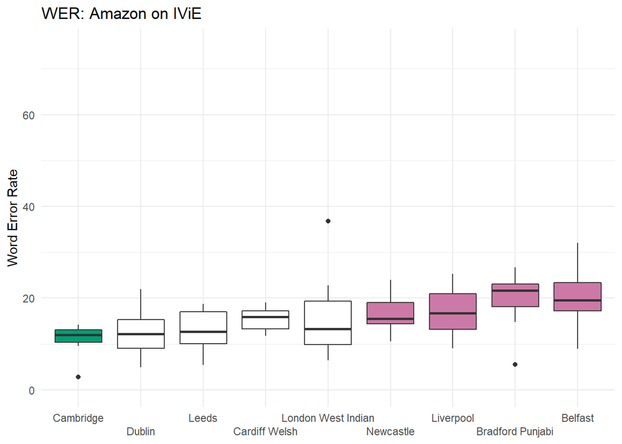

```r
ivie_rea1_wide%>%
  mutate(stat_sig = case_when(variety == "Cambridge" ~ 1,
                              variety %in% c("Belfast", "Bradford Punjabi", "Liverpool", "Newcastle") ~ 3,
                              TRUE ~ 2))%>%
  ggplot(aes(reorder(variety, WER_Amazon), WER_Amazon, fill =as.factor(stat_sig)))+
  geom_boxplot()+
    theme_minimal()+

  scale_fill_manual(breaks = c(1, 2, 3), values = c("#009E73", "#FFFFFF", "#CC79A7"))+
  scale_x_discrete(guide = guide_axis(n.dodge=2))+
  theme(legend.position = "none")+
 ylim(0, 75)+
  ylab("Word Error Rate")+
     theme(axis.title.x=element_blank())+

  ggtitle("WER: Amazon on IViE")
```

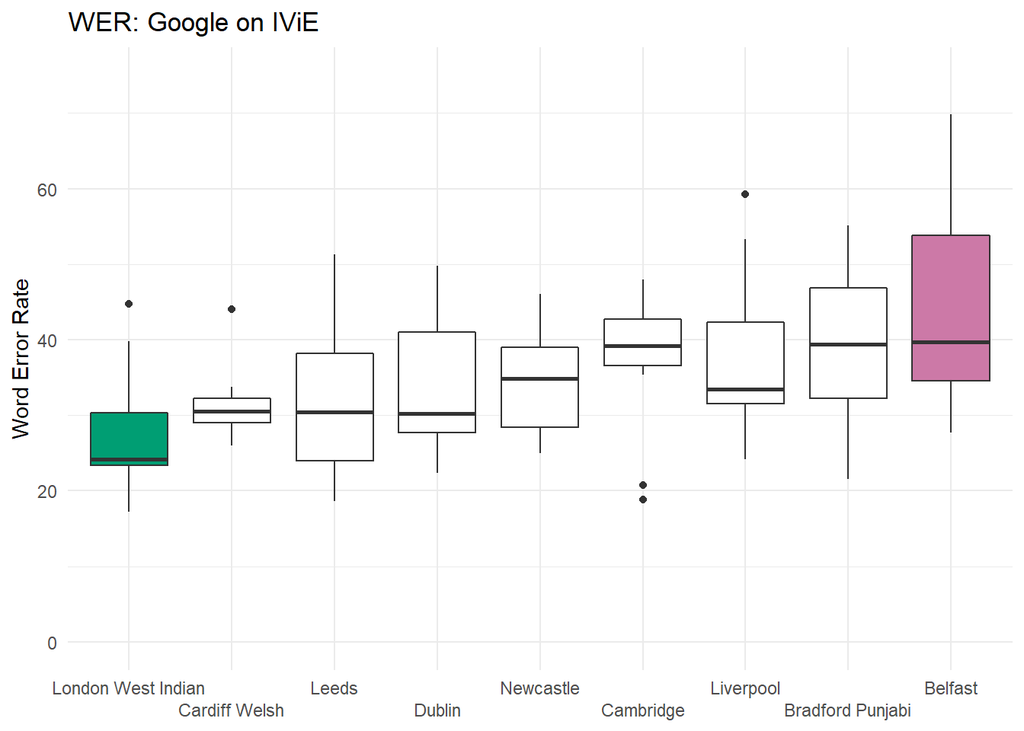

```r
ivie_rea1_wide%>%
  mutate(stat_sig = case_when(variety == "London West Indian" ~ 1,
                              variety %in% c("Belfast") ~ 3,
                              TRUE ~ 2))%>%
  ggplot(aes(reorder(variety, WER_Google), WER_Google, fill =as.factor(stat_sig)))+
  geom_boxplot()+
    theme_minimal()+

  scale_fill_manual(breaks = c(1, 2, 3), values = c("#009E73", "#FFFFFF", "#CC79A7"))+
  scale_x_discrete(guide = guide_axis(n.dodge=2))+
  theme(legend.position = "none")+
  ylim(0, 75)+
  ylab("Word Error Rate")+
     theme(axis.title.x=element_blank())+

  ggtitle("WER: Google on IViE")
```

```r
ivie_plot_data_ama <- ivie_rea1_wide%>%
mutate(stat_sig = case_when(variety == "Cambridge" ~ 1,
                              variety %in% c("Belfast", "Bradford Punjabi", "Liverpool", "Newcastle") ~ 3,
                              TRUE ~ 2))

ivie_plot_data_ama$variety <- factor(ivie_plot_data_ama$variety, levels = c("Cambridge", "Cardiff Welsh", "Dublin", "London West Indian", "Leeds", "Bradford Punjabi", "Liverpool" , "Newcastle", "Belfast"))


p1 = ggplot(data = ivie_plot_data_ama, aes(y = Gender, x = WER_Amazon, fill = Gender)) +
   geom_boxplot()+
  scale_fill_colorblind()+
  facet_wrap(~variety, ncol = 2)+
   theme(legend.position = "none")+
  xlab("Word Error Rate")


dummy <- ggplot(data = ivie_plot_data_ama, aes(y = Gender, x = WER_Amazon))+ facet_wrap(~variety, ncol =2) +
  geom_rect(aes(fill=as.factor(stat_sig)), xmin=-Inf, xmax=Inf, ymin=-Inf, ymax=Inf) +
  scale_fill_manual(breaks = c(1, 2, 3), values = c("#009E73", "#F0E442", "#CC79A7"))+
  theme_minimal()

g1 <- ggplotGrob(p1)
g2 <- ggplotGrob(dummy)

gtable_select <- function (x, ...)
{
  matches <- c(...)
  x$layout <- x$layout[matches, , drop = FALSE]
  x$grobs <- x$grobs[matches]
  x
}

panels <- grepl(pattern="panel", g2$layout$name)
strips <- grepl(pattern="strip_t", g2$layout$name)
stript <- grepl(pattern="strip-t", g2$layout$name)
g2$layout$t[panels] <- g2$layout$t[panels] - 1
g2$layout$b[panels] <- g2$layout$b[panels] - 1

new_strips <- gtable_select(g2, panels | strips | stript)
#grid.newpage()
#grid.draw(new_strips)

gtable_stack <- function(g1, g2){
  g1$grobs <- c(g1$grobs, g2$grobs)
  g1$layout <- transform(g1$layout, z= z-max(z), name="g2")
  g1$layout <- rbind(g1$layout, g2$layout)
  g1
}
## ideally you'd remove the old strips, for now they're just covered
new_plot <- gtable_stack(g1, new_strips)
#grid.newpage()
#grid.draw(new_plot)

ggsave("amazon_ivie_gender_horizontal.svg", new_plot, width = 6, height = 8)
```

```r
newplot1 <-
  ivie_rea1_wide%>%
  filter(variety == "Cambridge")%>%
  ggplot( aes(y = Gender, x = WER_Amazon, fill = Gender)) +
   geom_boxplot()+
  scale_fill_colorblind()+
  facet_wrap(~variety, ncol = 2)+
   theme(legend.position = "none",
        axis.title.x=element_blank(),
        axis.title.y=element_blank())+
  xlim(0, 40)
```

```r
ivie_plot_data_ama1 <- ivie_rea1_wide%>%
  filter(variety != "Cambridge")%>%
  mutate(stat_sig = case_when(variety %in% c("Belfast", "Bradford Punjabi", "Liverpool", "Newcastle") ~ 3,
                              TRUE ~ 2))

ivie_plot_data_ama1$variety <- factor(ivie_plot_data_ama1$variety, levels = c("Cardiff Welsh", "Dublin", "London West Indian", "Leeds", "Bradford Punjabi", "Liverpool" , "Newcastle", "Belfast"))


p2 = ggplot(data = ivie_plot_data_ama1, aes(y = Gender, x = WER_Amazon, fill = Gender)) +
   geom_boxplot()+
  scale_fill_colorblind()+
  facet_wrap(~variety, ncol = 2)+
   theme(legend.position = "none")+
  xlab("Word Error Rate")+
    xlim(0, 40)



dummy <- ggplot(data = ivie_plot_data_ama1, aes(y = Gender, x = WER_Amazon))+ facet_wrap(~variety, ncol =2) +
  geom_rect(aes(fill=as.factor(stat_sig)), xmin=-Inf, xmax=Inf, ymin=-Inf, ymax=Inf) +
  scale_fill_manual(breaks = c(2, 3), values = c("#F0E442", "#CC79A7"))+
  theme_minimal()

g1 <- ggplotGrob(p2)
g2 <- ggplotGrob(dummy)

gtable_select <- function (x, ...)
{
  matches <- c(...)
  x$layout <- x$layout[matches, , drop = FALSE]
  x$grobs <- x$grobs[matches]
  x
}

panels <- grepl(pattern="panel", g2$layout$name)
strips <- grepl(pattern="strip_t", g2$layout$name)
stript <- grepl(pattern="strip-t", g2$layout$name)
g2$layout$t[panels] <- g2$layout$t[panels] - 1
g2$layout$b[panels] <- g2$layout$b[panels] - 1

new_strips <- gtable_select(g2, panels | strips | stript)
#grid.newpage()
#grid.draw(new_strips)

gtable_stack <- function(g1, g2){
  g1$grobs <- c(g1$grobs, g2$grobs)
  g1$layout <- transform(g1$layout, z= z-max(z), name="g2")
  g1$layout <- rbind(g1$layout, g2$layout)
  g1
}
## ideally you'd remove the old strips, for now they're just covered
new_plot2 <- gtable_stack(g1, new_strips)
#grid.newpage()
#grid.draw(new_plot2)

#ggsave("amazon_ivie_gender_horizontal2.svg", new_plot, width = 6, height = 8)
```

```r
new_plot1 <- cowplot::plot_grid(NULL, newplot1, NULL, align = "v", nrow = 1,  rel_widths = c(1/4, 1/2, 1/4))
full_plot <- cowplot::plot_grid(new_plot1, new_plot2, align = "v", nrow = 2,  rel_heights = c(1/5,4/5))

#ggsave("amazon_ivie_gender_horizontal_full.svg", full_plot, width = 6, height = 8)
```

```r
ivie_plot_data_ama1 <- ivie_rea1_wide%>%
  filter(variety != "Cambridge")%>%
  mutate(stat_sig = case_when(variety %in% c("Belfast", "Bradford Punjabi", "Liverpool", "Newcastle") ~ 3,
                              TRUE ~ 2))

ivie_plot_data_ama1$variety <- factor(ivie_plot_data_ama1$variety, levels = c("Cardiff Welsh", "Dublin", "London West Indian", "Leeds", "Bradford Punjabi", "Liverpool" , "Newcastle", "Belfast"))


p2 = ggplot(data = ivie_plot_data_ama1, aes(y = Gender, x = WER_Amazon, fill = Gender)) +
   geom_boxplot()+
  scale_fill_colorblind()+
  facet_wrap(~variety, ncol = 2)+
   theme(legend.position = "none")+
  xlab("Word Error Rate")


dummy <- ggplot(data = ivie_plot_data_ama1, aes(y = Gender, x = WER_Amazon))+ facet_wrap(~variety, ncol =2) +
  geom_rect(aes(fill=as.factor(stat_sig)), xmin=-Inf, xmax=Inf, ymin=-Inf, ymax=Inf) +
  scale_fill_manual(breaks = c(2, 3), values = c("#F0E442", "#CC79A7"))+
  theme_minimal()

g1 <- ggplotGrob(p2)
g2 <- ggplotGrob(dummy)

gtable_select <- function (x, ...)
{
  matches <- c(...)
  x$layout <- x$layout[matches, , drop = FALSE]
  x$grobs <- x$grobs[matches]
  x
}

panels <- grepl(pattern="panel", g2$layout$name)
strips <- grepl(pattern="strip_t", g2$layout$name)
stript <- grepl(pattern="strip-t", g2$layout$name)
g2$layout$t[panels] <- g2$layout$t[panels] - 1
g2$layout$b[panels] <- g2$layout$b[panels] - 1

new_strips <- gtable_select(g2, panels | strips | stript)
#grid.newpage()
#grid.draw(new_strips)

gtable_stack <- function(g1, g2){
  g1$grobs <- c(g1$grobs, g2$grobs)
  g1$layout <- transform(g1$layout, z= z-max(z), name="g2")
  g1$layout <- rbind(g1$layout, g2$layout)
  g1
}
## ideally you'd remove the old strips, for now they're just covered
new_plot2 <- gtable_stack(g1, new_strips)
#grid.newpage()
#grid.draw(new_plot)

#ggsave("amazon_ivie_gender_horizontal2.svg", new_plot, width = 6, height = 8)
```

```r
ivie_plot_data_google <- ivie_rea1_wide%>%
mutate(stat_sig = case_when(variety == "London West Indian" ~ 1,
                              variety %in% c("Belfast") ~ 3,
                              TRUE ~ 2))

ivie_plot_data_google$variety <- factor(ivie_plot_data_google$variety, levels = c("London West Indian", "Cambridge", "Cardiff Welsh", "Dublin",  "Leeds", "Bradford Punjabi", "Liverpool" , "Newcastle", "Belfast"))


p1 = ggplot(data = ivie_plot_data_google, aes(x = Gender, y = WER_Google, fill = Gender)) +
   geom_boxplot()+
  scale_fill_colorblind()+
  facet_wrap(~variety, ncol = 2)+
   theme(legend.position = "none")+
  ylab("Word Error Rate")


dummy <- ggplot(data = ivie_plot_data_google, aes(x = Gender, y = WER_Google))+ facet_wrap(~variety, ncol = 2) +
  geom_rect(aes(fill=as.factor(stat_sig)), xmin=-Inf, xmax=Inf, ymin=-Inf, ymax=Inf) +
  scale_fill_manual(breaks = c(1, 2, 3), values = c("#009E73", "#F0E442", "#CC79A7"))+
  theme_minimal()

g1 <- ggplotGrob(p1)
g2 <- ggplotGrob(dummy)

gtable_select <- function (x, ...)
{
  matches <- c(...)
  x$layout <- x$layout[matches, , drop = FALSE]
  x$grobs <- x$grobs[matches]
  x
}

panels <- grepl(pattern="panel", g2$layout$name)
strips <- grepl(pattern="strip_t", g2$layout$name)
stript <- grepl(pattern="strip-t", g2$layout$name)
g2$layout$t[panels] <- g2$layout$t[panels] - 1
g2$layout$b[panels] <- g2$layout$b[panels] - 1

new_strips <- gtable_select(g2, panels | strips | stript)
#grid.newpage()
##grid.draw(new_strips)

gtable_stack <- function(g1, g2){
  g1$grobs <- c(g1$grobs, g2$grobs)
  g1$layout <- transform(g1$layout, z= z-max(z), name="g2")
  g1$layout <- rbind(g1$layout, g2$layout)
  g1
}
## ideally you'd remove the old strips, for now they're just covered
new_plot <- gtable_stack(g1, new_strips)
#grid.newpage()
#rid.draw(new_plot)

#ggsave("google_ivie_gender.svg", plot = new_plot,  width = 6, height = 8)
```

```r
newplot3 <-
  ivie_rea1_wide%>%
  filter(variety == "London West Indian")%>%
  ggplot( aes(y = Gender, x = WER_Google, fill = Gender)) +
   geom_boxplot()+
  scale_fill_colorblind()+
  facet_wrap(~variety, ncol = 2)+
   theme(legend.position = "none",
        axis.title.x=element_blank(),
        axis.title.y=element_blank())+
  xlim(0, 70)
```

```r
ivie_plot_data_google1 <- ivie_rea1_wide%>%
  filter(variety != "London West Indian")%>%
mutate(stat_sig = case_when(variety %in% c("Belfast") ~ 3,
                              TRUE ~ 2))

ivie_plot_data_google1$variety <- factor(ivie_plot_data_google1$variety, levels = c("Cambridge", "Cardiff Welsh", "Dublin",  "Leeds", "Bradford Punjabi", "Liverpool" , "Newcastle", "Belfast"))


p4 = ggplot(data = ivie_plot_data_google1, aes(y = Gender, x = WER_Google, fill = Gender)) +
   geom_boxplot()+
  scale_fill_colorblind()+
  facet_wrap(~variety, ncol = 2)+
  xlab("Word Error Rate")+
  ylab("Gender")+
     theme(legend.position = "none")



dummy <- ggplot(data = ivie_plot_data_google1, aes(y = Gender, x = WER_Google))+ facet_wrap(~variety, ncol = 2) +
  geom_rect(aes(fill=as.factor(stat_sig)), xmin=-Inf, xmax=Inf, ymin=-Inf, ymax=Inf) +
  scale_fill_manual(breaks = c(2, 3), values = c("#F0E442", "#CC79A7"))+
  theme_minimal()

g4 <- ggplotGrob(p4)
g2 <- ggplotGrob(dummy)

gtable_select <- function (x, ...)
{
  matches <- c(...)
  x$layout <- x$layout[matches, , drop = FALSE]
  x$grobs <- x$grobs[matches]
  x
}

panels <- grepl(pattern="panel", g2$layout$name)
strips <- grepl(pattern="strip_t", g2$layout$name)
stript <- grepl(pattern="strip-t", g2$layout$name)
g2$layout$t[panels] <- g2$layout$t[panels] - 1
g2$layout$b[panels] <- g2$layout$b[panels] - 1

new_strips <- gtable_select(g2, panels | strips | stript)

gtable_stack <- function(g4, g2){
  g4$grobs <- c(g4$grobs,g2$grobs)
  g4$layout <- transform(g4$layout, z= z-max(z), name="g2")
  g4$layout <- rbind(g4$layout, g2$layout)
  g4
}
## ideally you'd remove the old strips, for now they're just covered
new_plot4 <- gtable_stack(g4, new_strips)

#ggsave("google_ivie_gender.svg", plot = new_plot,  width = 6, height = 8)
```

```r
new_plot3 <- cowplot::plot_grid(NULL, newplot3, NULL, align = "v", nrow = 1,  rel_widths = c(1/4, 1/2, 1/4))
full_plot2 <- cowplot::plot_grid(new_plot3, new_plot4, align = "v", nrow = 2,  rel_heights = c(1/5, 4/5))

#ggsave("google_ivie_gender_horizontal_full.svg", full_plot2, width = 6, height = 8)
```

## 8.2 SAA

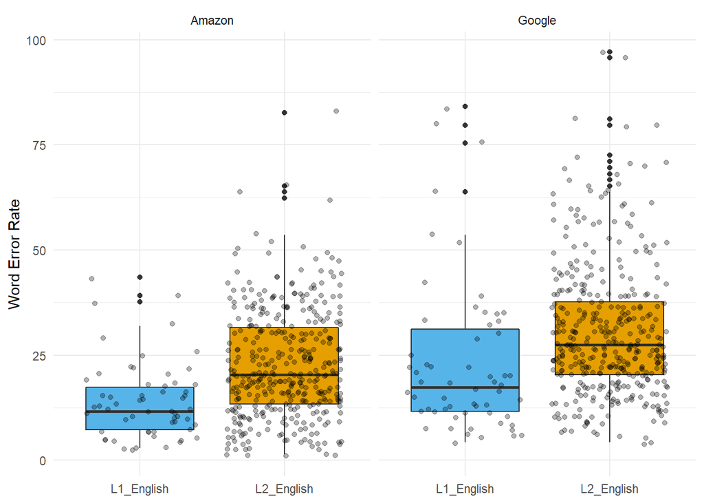

```r
saa_stella_long%>%
  ggplot(aes(as.factor(L1_english), WER, fill = L1_english))+
  geom_boxplot()+
  geom_jitter(alpha = 0.3) +
  facet_grid(~system)+
    scale_fill_manual(values = c("#56B4E9", "#E69F00"))+
    theme_minimal()+
  theme(legend.position = "none",
        axis.title.x = element_blank()) +
  ylab("Word Error Rate")
```

```r
  ggtitle("Word Error Rate (WER): Speech Accent Archive")
```

```
## $title
## [1] "Word Error Rate (WER): Speech Accent Archive"
##
## attr(,"class")
## [1] "labels"
```

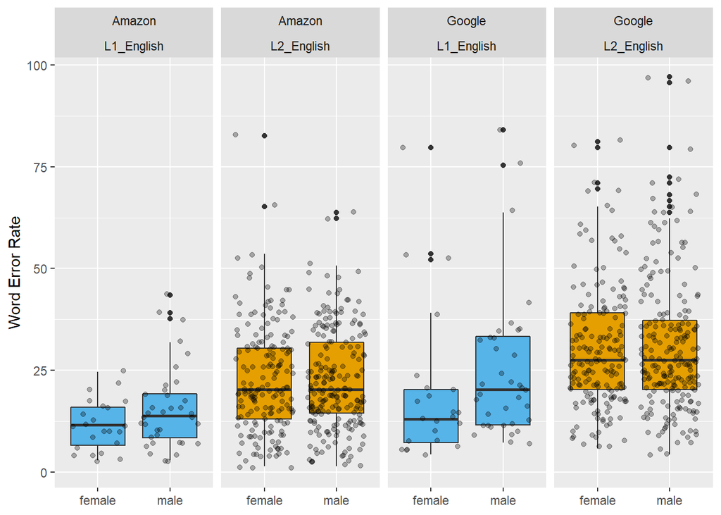

```r
saa_stella_long%>%
  ggplot(aes(as.factor(sex), WER, fill = L1_english))+
  geom_boxplot()+
  geom_jitter(alpha = 0.3) +
  facet_grid(~system*L1_english)+
    scale_fill_manual(values = c("#56B4E9", "#E69F00"))+
  #  theme_minimal()+
  theme(legend.position = "none",
        axis.title.x = element_blank())+
  ylab("Word Error Rate")
```